# Prediction - Exercises

Anna Hołdyńska

14th June 2022

## Exercises and Answers

1. **Dataset `cars` contains two columns: speed (`speed`) and stopping distance (`dist`).**  
   **- draw a plot to see how the data looks**  
   **- create a linear regression model and add regression line to plot**  
   **- create a quadratic regression model and add regression line to plot**  
   **- consider which model is better and predict `dist` value, when `speed` is 40.**

Proposed answer:

```r
?cars

plot(cars, pch = 21)

# linear regression model
model_lin <- lm(dist ~ speed, data = cars)
abline(model_lin, col = "darkred", lwd = 2)
summary(model_lin)
```

```
##
## Call:
## lm(formula = dist ~ speed, data = cars)
##
## Residuals:
##     Min      1Q  Median      3Q     Max
## -29.069  -9.525  -2.272   9.215  43.201
##
## Coefficients:
##             Estimate Std. Error t value Pr(>|t|)
## (Intercept) -17.5791     6.7584  -2.601   0.0123 *
## speed         3.9324     0.4155   9.464 1.49e-12 ***
## ---
## Signif. codes:  0 '***' 0.001 '**' 0.01 '*' 0.05 '.' 0.1 ' ' 1
##
## Residual standard error: 15.38 on 48 degrees of freedom
## Multiple R-squared:  0.6511, Adjusted R-squared:  0.6438
## F-statistic: 89.57 on 1 and 48 DF,  p-value: 1.49e-12
```

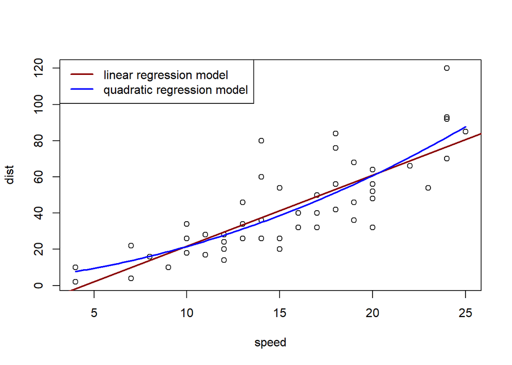

```r
# quadratic regression model
model_qua <- lm(dist ~ speed + I(speed^2), data = cars)
coefs <- coef(model_qua)
curve(coefs[1] + coefs[2] * x + coefs[3] * x^2,
      add = TRUE,
      col = "blue",
      lwd = 2)

# adding legend to plot
legend("topleft",
       legend = c("linear regression model", "quadratic regression model"),
       col = c("darkred", "blue"),
       lty = 1,
       lwd = 2)
```

```r
summary(model_qua)
```

```
##
## Call:
## lm(formula = dist ~ speed + I(speed^2), data = cars)
##
## Residuals:
##     Min      1Q  Median      3Q     Max
## -28.720  -9.184  -3.188   4.628  45.152
##
## Coefficients:
##             Estimate Std. Error t value Pr(>|t|)
## (Intercept)  2.47014   14.81716   0.167    0.868
## speed        0.91329    2.03422   0.449    0.656
## I(speed^2)   0.09996    0.06597   1.515    0.136
##
## Residual standard error: 15.18 on 47 degrees of freedom
## Multiple R-squared:  0.6673, Adjusted R-squared:  0.6532
## F-statistic: 47.14 on 2 and 47 DF,  p-value: 5.852e-12
```

```r
# looking at the R^2, quadratic model is better

# prediction
predict(model_qua, list(speed = 40))
```

```
##        1
## 198.9365
```

2. **Using dataset `Boston` from `MASS` package, fit a polynomial regression model.**  
   **- draw a plot to see how the data looks (choose x value as `medv` and y as `lstat`)**  
   **- create a polynomial regression models (`lstat` is dependent variable and `medv` is independent variable) with different levels of the polynomial. In your opinion, which is the best? (use measures from lecture)**  
   **- using the best polynomial regression model, predict `lstat` value where `medv` = 50.04**

Proposed answer:

```r
#install.packages("MASS")
library(MASS)
?Boston

plot(Boston$medv, Boston$lstat)

# 2th level
model1 <- lm(lstat ~ medv + I(medv^2), data = Boston)
coefs <- coef(model1)
curve(coefs[1] + coefs[2] * x + coefs[3] * x^2,
      add = TRUE,
      col = "darkred",
      lwd = 2)
summary(model1)
```

```
##
## Call:
## lm(formula = lstat ~ medv + I(medv^2), data = Boston)
##
## Residuals:
##     Min      1Q  Median      3Q     Max
## -13.688  -2.550  -0.443   1.675  19.529
##
## Coefficients:
##              Estimate Std. Error t value Pr(>|t|)
## (Intercept) 39.047643   1.044126   37.40   <2e-16 ***
## medv        -1.715027   0.081046  -21.16   <2e-16 ***
## I(medv^2)    0.020687   0.001424   14.53   <2e-16 ***
## ---
## Signif. codes:  0 '***' 0.001 '**' 0.01 '*' 0.05 '.' 0.1 ' ' 1
##
## Residual standard error: 4.055 on 503 degrees of freedom
## Multiple R-squared:  0.6789, Adjusted R-squared:  0.6776
## F-statistic: 531.7 on 2 and 503 DF,  p-value: < 2.2e-16
```

```r
# 3th level
model2 <- lm(lstat ~ medv + I(medv^2) + I(medv^3), data = Boston)
coefs <- coef(model2)
curve(coefs[1] + coefs[2] * x + coefs[3] * x^2 + coefs[4] * x^3,
      add = TRUE,
      col = "blue",
      lwd = 2)
summary(model2)
```

```
##
## Call:
## lm(formula = lstat ~ medv + I(medv^2) + I(medv^3), data = Boston)
##
## Residuals:
##      Min       1Q   Median       3Q      Max
## -13.7027  -2.5645  -0.4597   1.7146  19.5425
##
## Coefficients:
##               Estimate Std. Error t value Pr(>|t|)
## (Intercept)  3.993e+01  2.073e+00  19.259  < 2e-16 ***
## medv        -1.841e+00  2.680e-01  -6.868 1.93e-11 ***
## I(medv^2)    2.586e-02  1.062e-02   2.435   0.0152 *
## I(medv^3)   -6.189e-05  1.259e-04  -0.492   0.6232
## ---
## Signif. codes:  0 '***' 0.001 '**' 0.01 '*' 0.05 '.' 0.1 ' ' 1
##
## Residual standard error: 4.058 on 502 degrees of freedom
## Multiple R-squared:  0.679,  Adjusted R-squared:  0.6771
## F-statistic:   354 on 3 and 502 DF,  p-value: < 2.2e-16
```

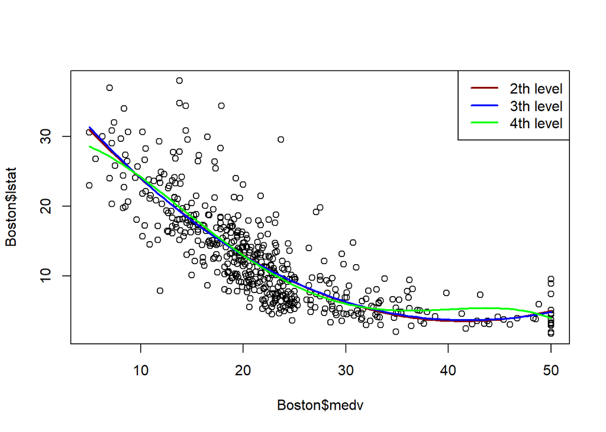

```r
# 4th level
model3 <- lm(lstat ~ medv + I(medv^2) + I(medv^3) + I(medv^4), data = Boston)
coefs <- coef(model3)
curve(coefs[1] + coefs[2] * x + coefs[3] * x^2 + coefs[4] * x^3 + coefs[5] * x^4,
      add = TRUE,
      col = "green",
      lwd = 2)
legend("topright",
       legend = c("2th level", "3th level", "4th level"),
       col = c("darkred", "blue", "green"),
       lty = 1,
       lwd = 2)
```

```r
summary(model3)
```

```
##
## Call:
## lm(formula = lstat ~ medv + I(medv^2) + I(medv^3) + I(medv^4),
##     data = Boston)
##
## Residuals:
##      Min       1Q   Median       3Q      Max
## -14.1885  -2.4067  -0.6392   1.7855  19.9394
##
## Coefficients:
##               Estimate Std. Error t value Pr(>|t|)
## (Intercept)  2.962e+01  4.031e+00   7.347 8.27e-13 ***
## medv         2.896e-01  7.641e-01   0.379  0.70488
## I(medv^2)   -1.175e-01  4.934e-02  -2.381  0.01764 *
## I(medv^3)    3.758e-03  1.291e-03   2.912  0.00375 **
## I(medv^4)   -3.460e-05  1.163e-05  -2.974  0.00308 **
## ---
## Signif. codes:  0 '***' 0.001 '**' 0.01 '*' 0.05 '.' 0.1 ' ' 1
##
## Residual standard error: 4.027 on 501 degrees of freedom
## Multiple R-squared:  0.6846, Adjusted R-squared:  0.6821
## F-statistic: 271.8 on 4 and 501 DF,  p-value: < 2.2e-16
```

```r
# In my opinion, 2th level is sufficient.
# There are very small differences at coefficient R^2.

# prediction
predict(model1, list(medv = 50.04))
```

```
##       1
## 5.02819
```

3. **Use dataset `marketing` from `datarium` package. Read more information about this dataset (`?marketing`). Create multiple regression model using method 1 or method 2 from the lecture. Predict `sales` value for your selected variable values.**

Proposed answer:

```r
# install.packages("datarium")
library(datarium)
?marketing

# multiple regression model
model <- lm(sales ~ ., data = marketing)
summary(model)
```

```
##
## Call:
## lm(formula = sales ~ ., data = marketing)
##
## Residuals:
##      Min       1Q   Median       3Q      Max
## -10.5932  -1.0690   0.2902   1.4272   3.3951
##
## Coefficients:
##              Estimate Std. Error t value Pr(>|t|)
## (Intercept)  3.526667   0.374290   9.422   <2e-16 ***
## youtube      0.045765   0.001395  32.809   <2e-16 ***
## facebook     0.188530   0.008611  21.893   <2e-16 ***
## newspaper   -0.001037   0.005871  -0.177     0.86
## ---
## Signif. codes:  0 '***' 0.001 '**' 0.01 '*' 0.05 '.' 0.1 ' ' 1
##
## Residual standard error: 2.023 on 196 degrees of freedom
## Multiple R-squared:  0.8972, Adjusted R-squared:  0.8956
## F-statistic: 570.3 on 3 and 196 DF,  p-value: < 2.2e-16
```

```r
# We use method 2 from the lecture
model2 <- step(model)
```

```
## Start:  AIC=285.72
## sales ~ youtube + facebook + newspaper
##
##             Df Sum of Sq    RSS    AIC
## - newspaper  1       0.1  802.0 283.75
## <none>                    801.8 285.72
## - facebook   1    1960.9 2762.7 531.13
## - youtube    1    4403.5 5205.4 657.83
##
## Step:  AIC=283.75
## sales ~ youtube + facebook
##
##            Df Sum of Sq    RSS    AIC
## <none>                   802.0 283.75
## - facebook  1    2225.7 3027.6 547.44
## - youtube   1    4408.7 5210.6 656.03
```

```r
summary(model2) # the best model
```

```
##
## Call:
## lm(formula = sales ~ youtube + facebook, data = marketing)
##
## Residuals:
##      Min       1Q   Median       3Q      Max
## -10.5572  -1.0502   0.2906   1.4049   3.3994
##
## Coefficients:
##             Estimate Std. Error t value Pr(>|t|)
## (Intercept)  3.50532    0.35339   9.919   <2e-16 ***
## youtube      0.04575    0.00139  32.909   <2e-16 ***
## facebook     0.18799    0.00804  23.382   <2e-16 ***
## ---
## Signif. codes:  0 '***' 0.001 '**' 0.01 '*' 0.05 '.' 0.1 ' ' 1
##
## Residual standard error: 2.018 on 197 degrees of freedom
## Multiple R-squared:  0.8972, Adjusted R-squared:  0.8962
## F-statistic: 859.6 on 2 and 197 DF,  p-value: < 2.2e-16
```

```r
# prediction
newdata = data.frame(youtube = 150,
                     facebook = 25)
predict(model2, newdata)
```

```
##       1
## 15.0684
```

4. **Let’s more predict. In chapter Logistic Regression is example: Fair’s Extramarital Affairs Data. Take the best chosen model and predict the probabilities of having affair for these new data:**  
   **- `rating` is 3, `age` is 20, `yearsmarried` is 2, `gender` is male and `religiousness` is 1**  
   **- `rating` is 5, `age` is 80, `yearsmarried` is 10 or 20, `gender` is female, religiousness` is 3**

Proposed answer:

```r
library(AER)
data(Affairs)
library(dplyr)
?Affairs

Affairs <- Affairs %>%
  mutate(ynaffairs = ifelse(affairs > 0, 1, 0))

model_glm <- glm(ynaffairs ~ gender + age +
                   yearsmarried + children +
                   religiousness + education +
                   occupation + rating,
                 data = Affairs,
                 family = 'binomial')
model_glm2 <- step(model_glm)
```

```
## Start:  AIC=627.51
## ynaffairs ~ gender + age + yearsmarried + children + religiousness +
##     education + occupation + rating
##
##                 Df Deviance    AIC
## - education      1   609.68 625.68
## - occupation     1   609.70 625.70
## - gender         1   610.89 626.89
## - children       1   611.40 627.40
## <none>               609.51 627.51
## - age            1   615.67 631.67
## - yearsmarried   1   618.34 634.34
## - religiousness  1   622.92 638.92
## - rating         1   636.75 652.75
##
## Step:  AIC=625.68
## ynaffairs ~ gender + age + yearsmarried + children + religiousness +
##     occupation + rating
##
##                 Df Deviance    AIC
## - occupation     1   610.15 624.15
## - gender         1   611.29 625.29
## - children       1   611.62 625.62
## <none>               609.68 625.68
## - age            1   615.78 629.78
## - yearsmarried   1   618.46 632.46
## - religiousness  1   623.27 637.27
## - rating         1   636.93 650.93
##
## Step:  AIC=624.15
## ynaffairs ~ gender + age + yearsmarried + children + religiousness +
##     rating
##
##                 Df Deviance    AIC
## - children       1   611.86 623.86
## <none>               610.15 624.15
## - gender         1   613.41 625.41
## - age            1   616.00 628.00
## - yearsmarried   1   619.07 631.07
## - religiousness  1   623.98 635.98
## - rating         1   637.23 649.23
##
## Step:  AIC=623.86
## ynaffairs ~ gender + age + yearsmarried + religiousness + rating
##
##                 Df Deviance    AIC
## <none>               611.86 623.86
## - gender         1   615.36 625.36
## - age            1   618.05 628.05
## - religiousness  1   625.57 635.57
## - yearsmarried   1   626.23 636.23
## - rating         1   639.93 649.93
```

```r
newdata1 <- data.frame(rating = 3,
                      age = 20,
                      yearsmarried = 2,
                      religiousness = 1,
                      gender = "male")
predict(model_glm2,
        newdata = newdata1,
        type = "response")
```

```
##         1
## 0.4872761
```

```r
newdata2 <- data.frame(rating = 5,
                      age = 80,
                      yearsmarried = c(10, 20),
                      religiousness = 3,
                      gender = "female")
predict(model_glm2,
        newdata = newdata2,
        type = "response")
```

```
##          1          2
## 0.02251841 0.06553592
```